# Lab 4

Amber Jacobson

October 10, 2017

## Question 1

The number of points scored by each team in a tournament is normally distributed, with mean μ = 32 and standard deviation σ = 7. What is the probability of:

### Part A

A team scoring 20 points or fewer? Plot the density function and shade the area. (5 pt.)

```r
pnorm(20, mean = 32, sd = 7)
```

```
## [1] 0.04323813
```

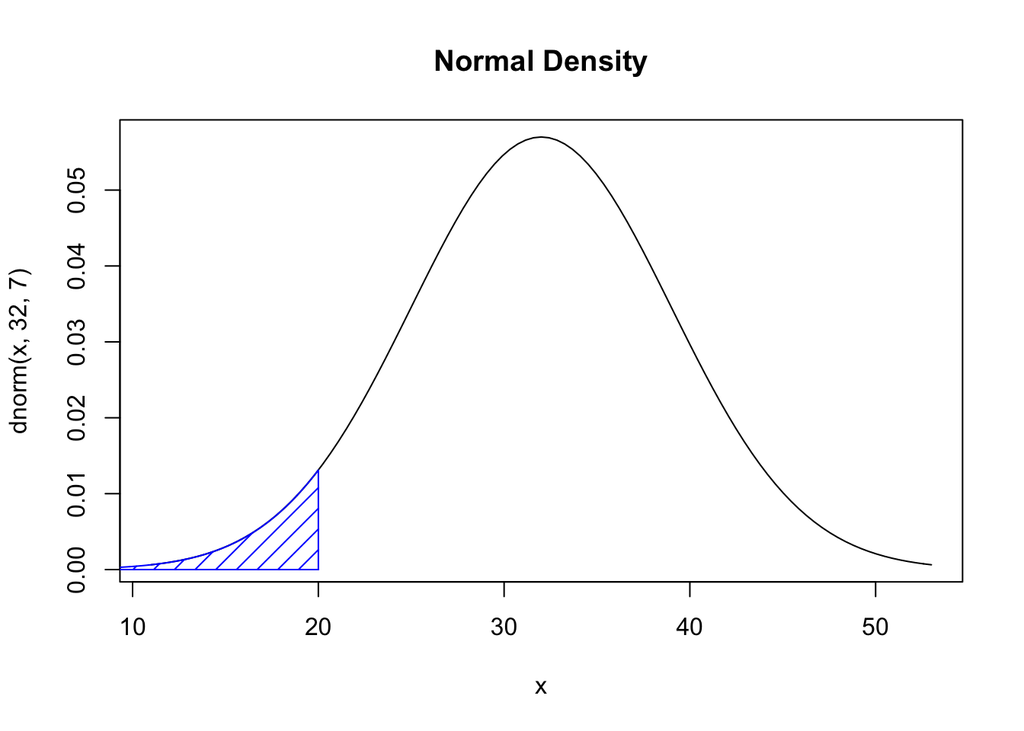

```r
cord.x <-  c(20, seq(0, 20, 0.01), 20)
cord.y <- c(0, dnorm(seq(0, 20, 0.01), mean = 32, sd = 7), 0)
curve(dnorm(x, 32, 7), xlim=c(11,53), main = "Normal Density")
polygon(cord.x,cord.y, density=10, col="blue")
```

```r
# Why is the equation used with pnorm then plotted with the dnorm function?
```

### Part B

A team scoring more than 35 points? Plot the density function and shade the area. (5 pt.)

```r
pnorm(35, mean =32, sd = 7, lower.tail = FALSE)
```

```
## [1] 0.3341176
```

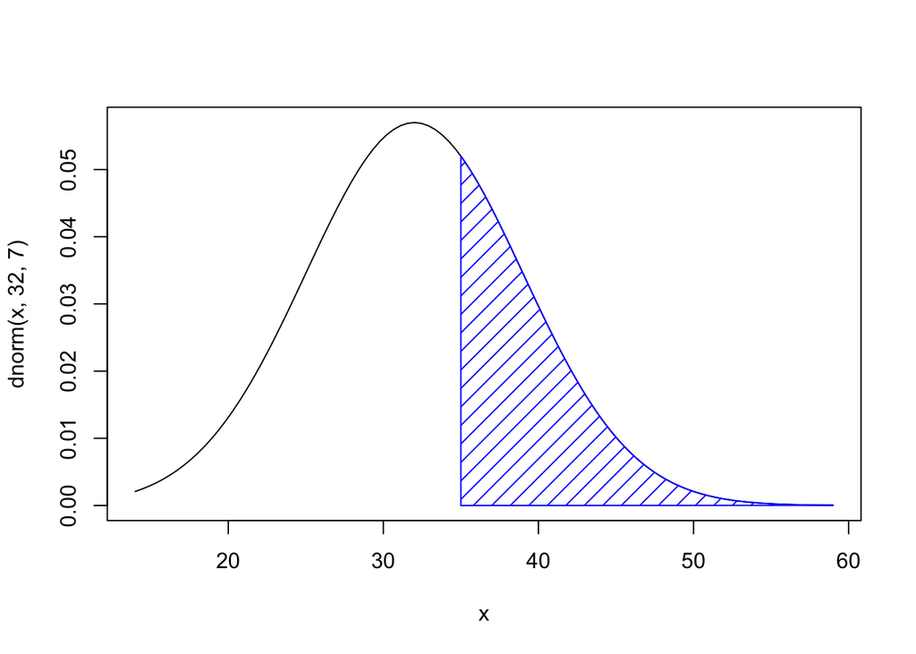

```r
curve(dnorm(x, 32, 7), xlim=c(14, 59))
cord.x <- c(35, seq(35, 59, .01), 35)
cord.y <- c(0, dnorm(seq(35, 59, 0.01), mean = 32, sd = 7), 0)
polygon(cord.x, cord.y, density=10, col="blue")
```

### Part C

A team scoring between 20 and 40 points? Plot the density function and shade the area.

```r
pnorm(40, mean = 32, sd = 7) - pnorm(20, mean = 32, sd = 7, lower.tail=FALSE)
```

```
## [1] -0.08331082
```

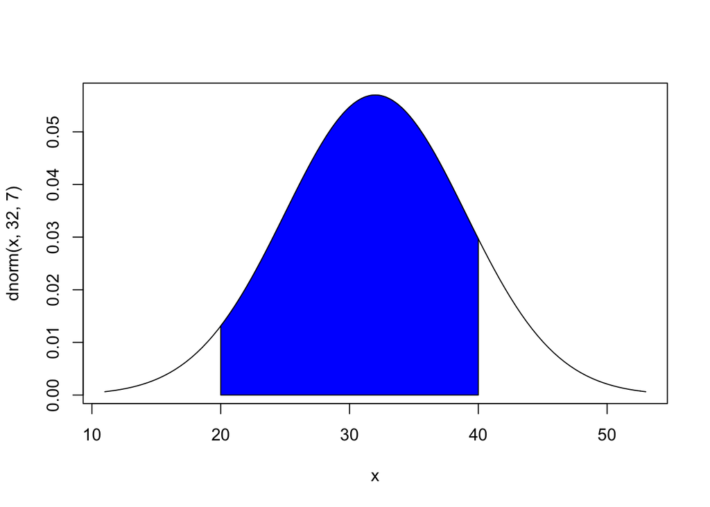

```r
curve(dnorm(x,32,7), from= 11, to= 53)
a <- c(20, seq(20,40,0.01), 40)
b <- c(0, dnorm(seq(20,40,0.01), mean=32, sd=7), 0)
polygon(a, b, col = "blue")
```

## Question 2

The number of comments per post on a social media site is exponentially distributed, with the average post receiving ten comments. What percentage of posts get:

### Part A

Fewer than three comments? Plot the density function and shade the area. (5 pt.)

```r
pexp(3, rate = 1/10 , lower.tail=TRUE)
```

```
## [1] 0.2591818
```

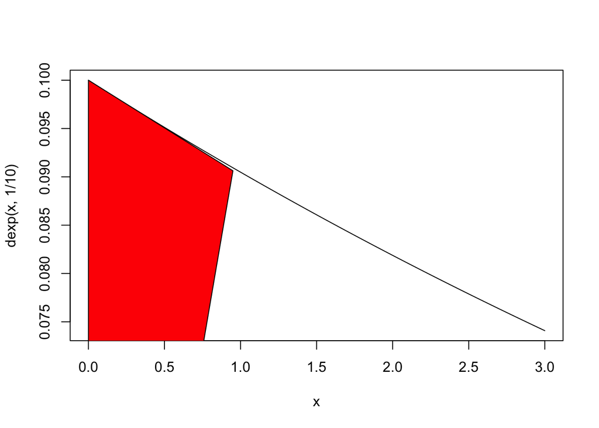

```r
curve(dexp(x,1/10), from =0, to=3)
c <- c(0, seq(0, .95, 0.001), 0)
d <- c(.1, pexp(seq(0, .95, 0.001), rate = 1/10), .1)
polygon(c,d,col="red")
```

### Part B

More than 20 comments? Plot the density function and shade the area. (5 pt.)

```r
pexp(20, rate = 1/10, lower.tail=FALSE)
```

```
## [1] 0.1353353
```

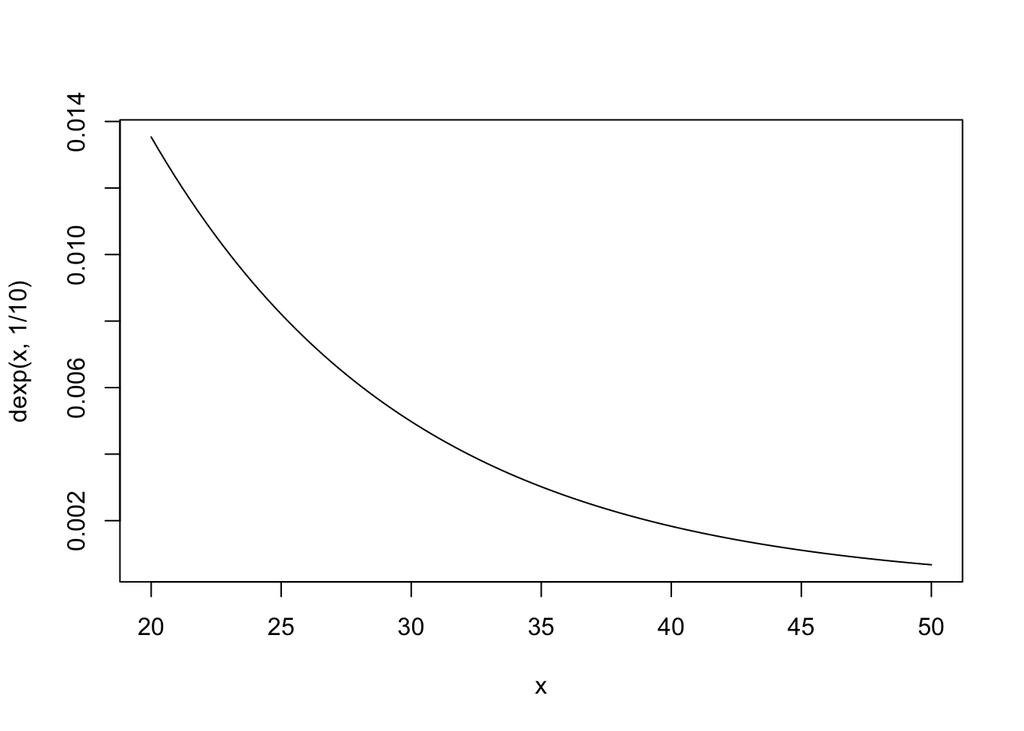

```r
curve(dexp(x,1/10), from =20, to=50)
e <- c(0, seq(0, .014, .01), 0)
f <- c(20, pexp(seq(0,.014,.01), rate = 1/10),20)
polygon(e,f,col="red")
```

### Part C

Between five and ten comments? Plot the density function and shade the area. (5 pt.)

```r
pexp(10, rate =1/10) - pexp(5, rate = 1/10)
```

```
## [1] 0.2386512
```

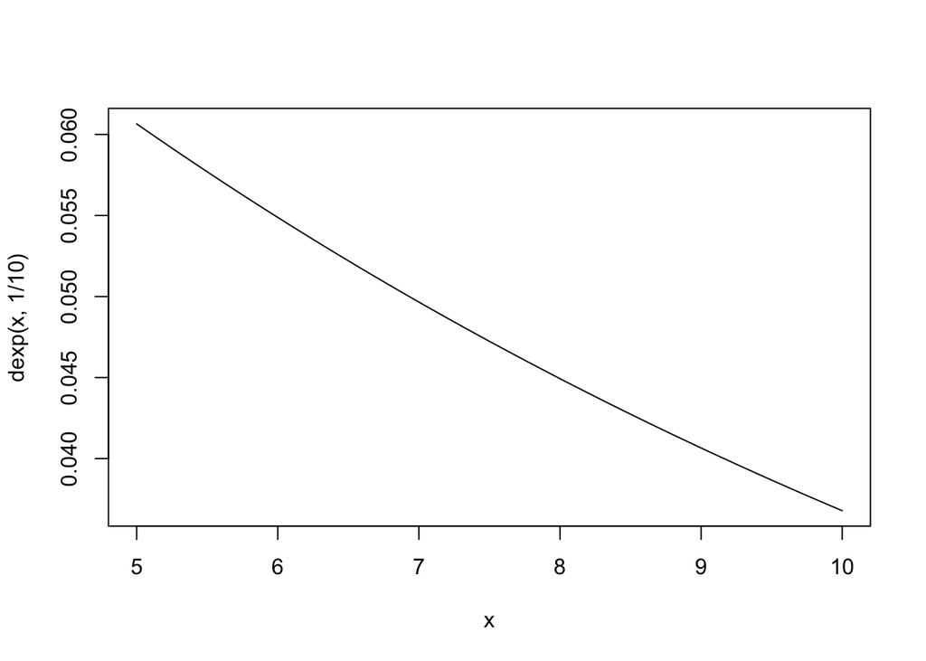

```r
curve(dexp(x,1/10), from =5, to=10)
e <- c(5, seq(0, .06, 0.01), .5)
f <- c(10, dexp(seq(0, .06, 0.01), rate = 1/10), 10)
polygon(e,f,col="red")
```

## Question 3

### Part A

Create a first raster (30 rows ×30 columns) and assign values to the raster based on random values from a uniform distribution. Plot the raster and the histogram. (5 pt.)

```r
library(raster)
```

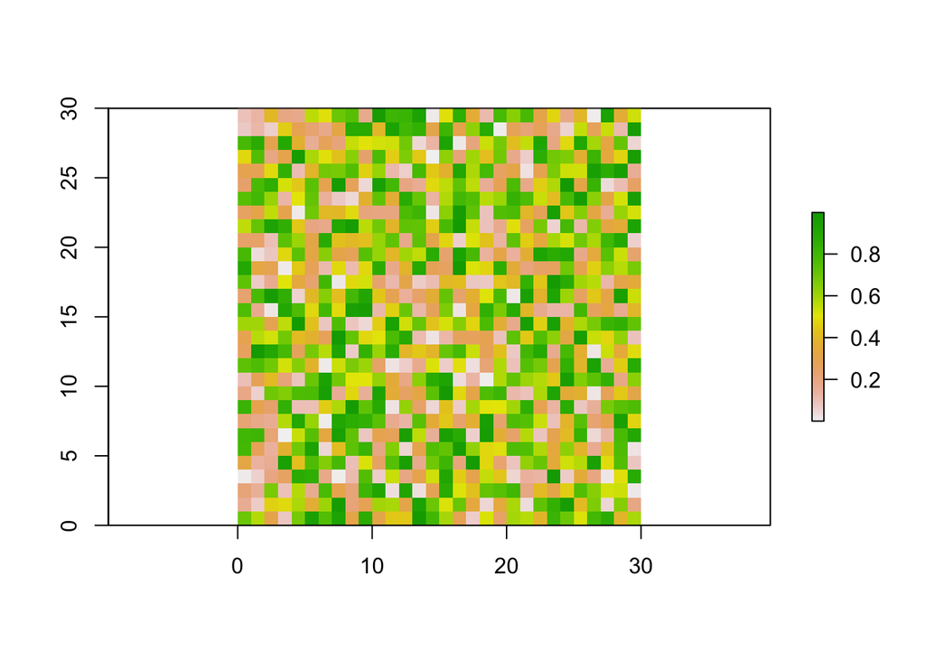

```r
ras1 <- raster(nrows=30, ncols=30, xmn=0, xmx=30, ymn=0, ymx=30)
ras1[] <- runif(ncell(ras1))
plot(ras1)
```

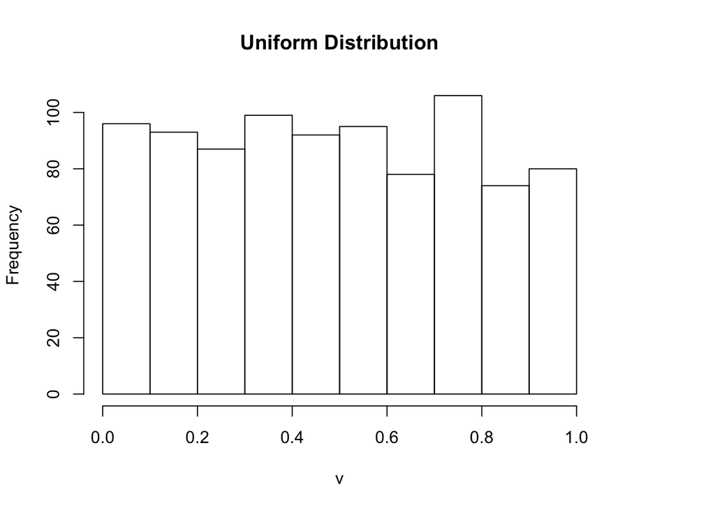

```r
hist(ras1, main = "Uniform Distribution")
```

### Part B

Create a second raster (30 rows ×30 columns) and assign values to the raster based on random values from a normal distribution. Plot the raster and the histogram. (5 pt.)

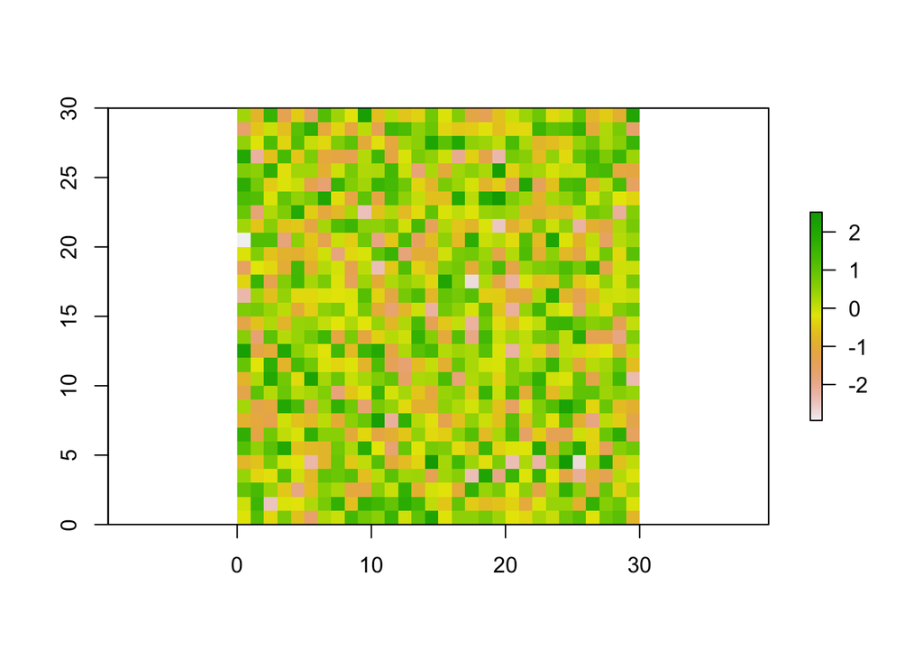

```r
library(raster)
ras2 <- raster(nrows=30, ncols=30, xmn=0, xmx=30, ymn=0, ymx=30)
ras2[] <- rnorm(ncell(ras2))
plot(ras2)
```

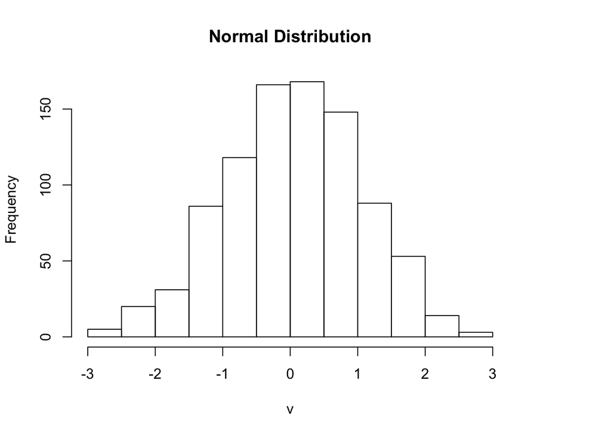

```r
hist(ras2, main="Normal Distribution")
```

### Part C

Create a third raster (30 rows ×30 columns) and assign values to the raster based on cell-by-cell addition of the first raster and the second raster. Plot the raster and the histogram. (5 pt.)

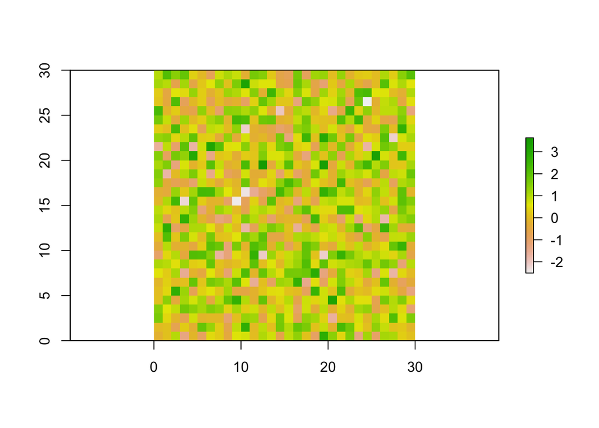

```r
library(raster)
ras1 <- raster(nrows=30, ncols=30, xmn=0, xmx=30, ymn=0, ymx=30)
ras1[] <- runif(ncell(ras1))
ras2 <- raster(nrows=30, ncols=30, xmn=0, xmx=30, ymn=0, ymx=30)
ras2[] <- rnorm(ncell(ras2))
ras3 <- ras1 + ras2
plot(ras3)
```

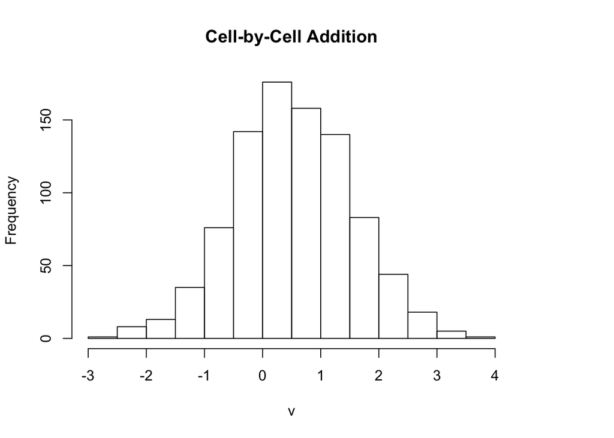

```r
hist(ras3, main="Cell-by-Cell Addition")
```

### Part D

Calculate the mean value of the third raster. Reclassify the third raster into a binary image: 1 (cell value > mean value) and 0 (cell value <= mean value). Save the reclassified image to your working directory as a TIFF image. (5 pt.)

```r
library(raster)
cellStats(ras3, "mean")
```

```
## [1] 0.5243299
```

```r
ras3[ras3 > 1/10] <- 1
ras3[ras3 <= 1/10] <- 0
rastif <- ras3 + ras3 * 10
writeRaster(rastif, filename="mean.tif", overwrite=TRUE)
```